# 金融数据分析与建模：作业二分析报告（Notebook 版）

**建议导出文件名：** `report.pdf`  
**当前 Notebook 文件建议命名：** `report.ipynb`

## 报告目的

本报告用于整合本次课程作业前五个 Notebook 的核心内容，形成一份**可独立阅读、可直接导出 PDF** 的完整分析报告。  
与前面 Notebook 相比，本报告不再把重点放在“逐步完成任务”，而是强调**研究脉络、数据结构、分析方法、主要结果与经济含义**的集中呈现。

## 报告结构

本报告按照作业要求组织为以下六个部分：

1. **数据说明与样本设计**
2. **数据存储与管理说明**
3. **数据清洗与结构转换说明**
4. **描述性统计与可视化分析**
5. **CAPM 与宏观回归分析**
6. **结论、局限与可改进方向**

## 阅读说明

- 本 Notebook 默认放在项目根目录 `dshw-p01/` 下运行。
- 它会自动读取前面步骤中已经生成好的 CSV、Parquet、PNG 和回归结果文件。
- 如果某些结果文件不存在，本报告会提示缺失项，但仍尽量继续运行。
- 导出 PDF 之前，建议先 **Run All**，确保图表、表格和文字输出全部显示在 Notebook 中。

```python
import sys
import subprocess
import importlib

required = ["pandas", "numpy", "matplotlib", "statsmodels", "pyarrow", "IPython"]
for pkg in required:
    try:
        importlib.import_module(pkg)
    except ImportError:
        subprocess.check_call([sys.executable, "-m", "pip", "install", pkg])

print("当前 Python：", sys.executable)
print("当前版本：", sys.version)
print("依赖检查完成。")
```

```
当前 Python： d:\Anaconda3\python.exe
当前版本： 3.13.9 | packaged by Anaconda, Inc. | (main, Oct 21 2025, 19:09:58) [MSC v.1929 64 bit (AMD64)]
依赖检查完成。
```

```python
from pathlib import Path
import time
import numpy as np
import pandas as pd
import matplotlib.pyplot as plt
from IPython.display import display, Markdown, Image

plt.rcParams["font.sans-serif"] = ["Microsoft YaHei", "SimHei", "Arial Unicode MS", "DejaVu Sans"]
plt.rcParams["axes.unicode_minus"] = False

ROOT = Path.cwd()
DATA_DIR = ROOT / "data"
STOCK_DIR = DATA_DIR / "stock"
INDEX_DIR = DATA_DIR / "index"
MACRO_DIR = DATA_DIR / "macro"
FINANCE_DIR = DATA_DIR / "finance"
CLEAN_DIR = DATA_DIR / "clean"
COMBINED_DIR = DATA_DIR / "combined"
OUTPUT_DIR = ROOT / "output"

def safe_read_csv(path, **kwargs):
    path = Path(path)
    if not path.exists():
        print(f"[缺失文件] {path}")
        return None
    df = pd.read_csv(path, **kwargs)
    unnamed = [c for c in df.columns if str(c).lower().startswith("unnamed")]
    if unnamed:
        df = df.drop(columns=unnamed)
    return df

def file_info(path):
    path = Path(path)
    if not path.exists():
        return {"path": str(path), "exists": False, "size_kb": None}
    return {"path": str(path), "exists": True, "size_kb": round(path.stat().st_size / 1024, 2)}

def display_png(path, width=None):
    path = Path(path)
    if path.exists():
        display(Image(filename=str(path), width=width))
    else:
        print(f"[缺失图片] {path}")

print("项目根目录：", ROOT)
print("数据目录：", DATA_DIR)
print("输出目录：", OUTPUT_DIR)
```

```
项目根目录： d:\Microsoft VS Code\dshw-p01
数据目录： d:\Microsoft VS Code\dshw-p01\data
输出目录： d:\Microsoft VS Code\dshw-p01\output
```

# 一、数据说明与样本设计

## 1.1 研究对象与样本范围

本次作业以 **10 只 A 股上市公司股票** 作为研究对象，覆盖银行、汽车、白酒、能源、通讯等多个行业。  
样本区间与课程要求一致，核心日度市场数据以 **2020-01-01 至当前下载日** 为时间范围，既保证了样本长度，也覆盖了疫情后市场波动、结构分化和宏观政策变化等重要阶段。

在数据层面，本项目同时使用了以下几类信息：

- **个股日度行情数据**：用于收益率、波动率、最大回撤、相关性和 CAPM 分析；
- **市场指数数据**：以沪深300为市场组合代理变量，支撑 CAPM 模型估计；
- **宏观指标数据**：用于分析利率或通胀因素对股票收益率的影响；
- **财务指标数据**：用于展示 ROE、资产负债率等企业基本面差异；
- **清洗与合并后的中间数据**：用于后续统计、可视化与回归分析。

## 1.2 数据来源说明

按照前面各 Notebook 的实现路径，数据来源如下：

- 个股、指数、财务指标：以 **baostock** 为主；
- 宏观指标：以 **AKShare** 获取的公开宏观数据为主；
- 数据管理与分析：主要使用 **pandas / pyarrow / matplotlib / statsmodels**；
- 报告图表：由前面分析 Notebook 生成并保存至 `output/` 目录。

## 1.3 报告写作思路

本报告不是简单复制前面每个 Notebook 的运行过程，而是将它们重新组织为一个完整研究闭环：

> 数据采集 → 数据存储 → 数据清洗 → 统计刻画 → 图形分析 → 回归检验 → 结论总结

因此，本报告中既保留关键代码块，也更加重视每一部分的解释性文字，使读者即使不翻看其他 Notebook，也能理解本项目的研究逻辑与主要发现。

```python
stock_universe = safe_read_csv(STOCK_DIR / "stock_universe.csv", dtype={"code": str})
stock_clean = safe_read_csv(CLEAN_DIR / "stock_clean.csv", dtype={"code": str})
index_300 = safe_read_csv(INDEX_DIR / "index_000300.csv")
index_001 = safe_read_csv(INDEX_DIR / "index_000001.csv")
macro_lpr = safe_read_csv(MACRO_DIR / "macro_lpr_1y.csv")
macro_cpi = safe_read_csv(MACRO_DIR / "macro_cpi_yoy.csv")
finance_long = safe_read_csv(FINANCE_DIR / "finance_long.csv", dtype={"code": str})
combined_data = safe_read_csv(COMBINED_DIR / "combined_data.csv", dtype={"code": str})

if stock_universe is not None:
    stock_universe["code"] = stock_universe["code"].astype(str).str.zfill(6)

if stock_clean is not None:
    stock_clean["code"] = stock_clean["code"].astype(str).str.zfill(6)
    if "date" in stock_clean.columns:
        stock_clean["date"] = pd.to_datetime(stock_clean["date"])

if finance_long is not None:
    finance_long["code"] = finance_long["code"].astype(str).str.zfill(6)

for idx_df in [index_300, index_001]:
    if idx_df is not None and "date" in idx_df.columns:
        idx_df["date"] = pd.to_datetime(idx_df["date"])

for macro_df in [macro_lpr, macro_cpi]:
    if macro_df is not None and "date" in macro_df.columns:
        macro_df["date"] = pd.to_datetime(macro_df["date"])

summary_rows = []

if stock_universe is not None:
    summary_rows.append({"数据表": "股票清单", "行数": len(stock_universe), "列数": stock_universe.shape[1], "起始日期": None, "结束日期": None})

if stock_clean is not None:
    summary_rows.append({
        "数据表": "清洗后个股面板",
        "行数": len(stock_clean),
        "列数": stock_clean.shape[1],
        "起始日期": str(stock_clean["date"].min().date()) if "date" in stock_clean.columns else None,
        "结束日期": str(stock_clean["date"].max().date()) if "date" in stock_clean.columns else None
    })

if index_300 is not None:
    summary_rows.append({
        "数据表": "沪深300指数",
        "行数": len(index_300),
        "列数": index_300.shape[1],
        "起始日期": str(index_300["date"].min().date()) if "date" in index_300.columns else None,
        "结束日期": str(index_300["date"].max().date()) if "date" in index_300.columns else None
    })

if index_001 is not None:
    summary_rows.append({
        "数据表": "上证综指",
        "行数": len(index_001),
        "列数": index_001.shape[1],
        "起始日期": str(index_001["date"].min().date()) if "date" in index_001.columns else None,
        "结束日期": str(index_001["date"].max().date()) if "date" in index_001.columns else None
    })

if macro_lpr is not None:
    summary_rows.append({
        "数据表": "1年期LPR",
        "行数": len(macro_lpr),
        "列数": macro_lpr.shape[1],
        "起始日期": str(macro_lpr["date"].min().date()) if "date" in macro_lpr.columns else None,
        "结束日期": str(macro_lpr["date"].max().date()) if "date" in macro_lpr.columns else None
    })

if macro_cpi is not None:
    summary_rows.append({
        "数据表": "CPI同比增速",
        "行数": len(macro_cpi),
        "列数": macro_cpi.shape[1],
        "起始日期": str(macro_cpi["date"].min().date()) if "date" in macro_cpi.columns else None,
        "结束日期": str(macro_cpi["date"].max().date()) if "date" in macro_cpi.columns else None
    })

if finance_long is not None:
    summary_rows.append({
        "数据表": "财务长表",
        "行数": len(finance_long),
        "列数": finance_long.shape[1],
        "起始日期": finance_long["year"].min() if "year" in finance_long.columns else None,
        "结束日期": finance_long["year"].max() if "year" in finance_long.columns else None
    })

sample_summary = pd.DataFrame(summary_rows)
display(sample_summary)

if stock_universe is not None:
    display(stock_universe)
```

|  | 数据表 | 行数 | 列数 | 起始日期 | 结束日期 |
| --- | --- | --- | --- | --- | --- |
| 0 | 股票清单 | 10 | 5 | None | None |
| 1 | 清洗后个股面板 | 15139 | 10 | 2020-01-02 | 2026-04-03 |
| 2 | 沪深300指数 | 1514 | 8 | 2020-01-02 | 2026-04-03 |
| 3 | 上证综指 | 1514 | 8 | 2020-01-02 | 2026-04-03 |
| 4 | 1年期LPR | 75 | 3 | 2020-01-20 | 2026-03-20 |
| 5 | CPI同比增速 | 68 | 3 | 2020-01-09 | 2025-08-09 |
| 6 | 财务长表 | 100 | 4 | 2020 | 2024 |

|  | code | bs_code | name | industry | reason |
| --- | --- | --- | --- | --- | --- |
| 0 | 600036 | sh.600036 | 招商银行 | 银行 | 零售银行代表性强，市场关注度高，适合作为银行板块样本。 |
| 1 | 601398 | sh.601398 | 工商银行 | 银行 | 大型国有银行代表，规模大、交易活跃，便于进行横向比较。 |
| 2 | 000625 | sz.000625 | 长安汽车 | 汽车 | 自主品牌车企代表，受行业景气与新能源转型影响明显。 |
| 3 | 600104 | sh.600104 | 上汽集团 | 汽车 | 传统整车龙头，适合与长安汽车做行业内比较。 |
| 4 | 600519 | sh.600519 | 贵州茅台 | 白酒 | 高端白酒龙头，估值和业绩都具有代表性。 |
| 5 | 000858 | sz.000858 | 五粮液 | 白酒 | 白酒核心龙头之一，可与茅台构成行业对照样本。 |
| 6 | 600028 | sh.600028 | 中国石化 | 能源 | 传统能源央企代表，受国际油价和宏观周期影响较强。 |
| 7 | 601857 | sh.601857 | 中国石油 | 能源 | 能源板块核心公司，行业代表性强，便于研究板块联动。 |
| 8 | 600050 | sh.600050 | 中国联通 | 通讯 | 基础电信运营商代表，适合观察稳健型行业特征。 |
| 9 | 000063 | sz.000063 | 中兴通讯 | 通讯 | 通信设备龙头之一，兼具成长性与行业波动特征。 |

```python
parts = []

if stock_universe is not None:
    n_stock = stock_universe["code"].nunique()
    n_industry = stock_universe["industry"].nunique() if "industry" in stock_universe.columns else "未知"
    parts.append(
        f"样本股票共 {n_stock} 只，覆盖 {n_industry} 个行业。"
        "这意味着本次作业不仅可以观察单只股票特征，还能比较行业之间的收益风险差异。"
    )

if stock_clean is not None and "date" in stock_clean.columns:
    start_date = stock_clean["date"].min().date()
    end_date = stock_clean["date"].max().date()
    parts.append(
        f"清洗后的个股日度数据覆盖区间为 {start_date} 至 {end_date}。"
        "这一时间跨度足以支持描述统计、图形分析和回归分析，并为 CAPM 估计提供较充足的日频样本。"
    )

if finance_long is not None:
    parts.append(
        "财务数据采用长格式整理，每行对应“某股票—某年度—某指标”的一条观测。"
        "这种结构便于后续按指标筛选、按公司分组绘图，也更适合与 pandas 的 groupby 和透视操作配合使用。"
    )

display(Markdown("\n\n".join(parts)))
```

样本股票共 10 只，覆盖 5 个行业。这意味着本次作业不仅可以观察单只股票特征，还能比较行业之间的收益风险差异。

清洗后的个股日度数据覆盖区间为 2020-01-02 至 2026-04-03。这一时间跨度足以支持描述统计、图形分析和回归分析，并为 CAPM 估计提供较充足的日频样本。

财务数据采用长格式整理，每行对应“某股票—某年度—某指标”的一条观测。这种结构便于后续按指标筛选、按公司分组绘图，也更适合与 pandas 的 groupby 和透视操作配合使用。

# 二、数据存储与管理说明

## 2.1 目录结构设计

第二部分的核心目标，是把原始下载数据、中间清洗结果、最终分析结果和报告文件放在统一的项目结构中。  
这种目录设计的优点在于：一方面便于复现，另一方面也有利于后续检查“原始数据—清洗数据—结果输出”之间的对应关系。

从研究规范角度看，清晰的目录结构至少有三层意义：

1. **可追溯性**：读者可以明确每个结果来自哪个中间文件；
2. **可复现性**：重新运行 Notebook 时，不需要重新手工整理路径；
3. **可维护性**：随着分析任务增加，不同类型文件不会混杂在同一目录中。

## 2.2 存储格式选择

本项目采用了课程要求的两层存储方式：

- **基础格式 A：CSV**  
  用于保存原始数据和大多数清洗后的表格，优点是兼容性高、可直接查看、跨软件使用方便；
- **进阶格式 B：Parquet**  
  用于保存清洗后的股票面板数据，主要目的是展示列式存储格式的优势，并与 CSV 做体积和读取性能对比。

其中，CSV 更适合教学展示和人工核查；Parquet 更适合后续列读取、高效压缩和更大规模的数据分析。

```python
key_files = [
    ROOT / "README.md",
    ROOT / "requirements.txt",
    ROOT / ".gitignore",
    ROOT / "download_log.txt",
    CLEAN_DIR / "stock_clean.csv",
    CLEAN_DIR / "stock_clean.parquet",
    COMBINED_DIR / "combined_data.csv",
    FINANCE_DIR / "finance_long.csv",
    OUTPUT_DIR / "descriptive_stats.csv",
    OUTPUT_DIR / "capm_results.csv",
]

inventory = pd.DataFrame([file_info(p) for p in key_files])
display(inventory)
```

|  | path | exists | size_kb |
| --- | --- | --- | --- |
| 0 | d:\Microsoft VS Code\dshw-p01\README.md | True | 5.68 |
| 1 | d:\Microsoft VS Code\dshw-p01\requirements.txt | True | 0.04 |
| 2 | d:\Microsoft VS Code\dshw-p01\.gitignore | True | 0.06 |
| 3 | d:\Microsoft VS Code\dshw-p01\download_log.txt | True | 1.58 |
| 4 | d:\Microsoft VS Code\dshw-p01\data\clean\stock... | True | 1732.32 |
| 5 | d:\Microsoft VS Code\dshw-p01\data\clean\stock... | True | 856.80 |
| 6 | d:\Microsoft VS Code\dshw-p01\data\combined\co... | True | 2908.78 |
| 7 | d:\Microsoft VS Code\dshw-p01\data\finance\fin... | True | 3.15 |
| 8 | d:\Microsoft VS Code\dshw-p01\output\descripti... | True | 1.30 |
| 9 | d:\Microsoft VS Code\dshw-p01\output\capm_resu... | True | 1.75 |

```python
csv_path = CLEAN_DIR / "stock_clean.csv"
parquet_path = CLEAN_DIR / "stock_clean.parquet"

if csv_path.exists() and parquet_path.exists():
    t0 = time.time()
    df_csv = pd.read_csv(csv_path)
    csv_read_time = time.time() - t0

    t0 = time.time()
    df_pq = pd.read_parquet(parquet_path)
    pq_read_time = time.time() - t0

    compare_df = pd.DataFrame({
        "格式": ["CSV", "Parquet"],
        "文件大小(KB)": [
            round(csv_path.stat().st_size / 1024, 2),
            round(parquet_path.stat().st_size / 1024, 2),
        ],
        "读取耗时(秒)": [
            round(csv_read_time, 4),
            round(pq_read_time, 4),
        ],
        "行数": [len(df_csv), len(df_pq)],
        "列数": [df_csv.shape[1], df_pq.shape[1]],
    })
    display(compare_df)

    try:
        import pyarrow.parquet as pq
        schema = pq.read_schema(parquet_path)
        print("Parquet Schema：")
        print(schema)
    except Exception as e:
        print("Schema 读取失败：", e)

    display(Markdown(
        "从本次样本规模看，CSV 与 Parquet 都足以完成课程作业。"
        "不过，Parquet 通常在文件压缩率、类型保留和列选择读取方面更有优势；当样本规模扩大到更长时间序列或更多股票时，这种优势会更加明显。"
    ))
else:
    print("未同时找到 stock_clean.csv 与 stock_clean.parquet，暂无法对比。")
```

|  | 格式 | 文件大小(KB) | 读取耗时(秒) | 行数 | 列数 |
| --- | --- | --- | --- | --- | --- |
| 0 | CSV | 1732.32 | 0.0300 | 15139 | 10 |
| 1 | Parquet | 856.80 | 0.0678 | 15139 | 10 |

```
Parquet Schema：
date: timestamp[ns]
code: string
open: double
close: double
high: double
low: double
volume: int64
amount: double
daily_return: double
is_extreme: bool
-- schema metadata --
pandas: '{"index_columns": [], "column_indexes": [], "columns": [{"name":' + 1198
```

从本次样本规模看，CSV 与 Parquet 都足以完成课程作业。不过，Parquet 通常在文件压缩率、类型保留和列选择读取方面更有优势；当样本规模扩大到更长时间序列或更多股票时，这种优势会更加明显。

## 2.3 核心代码示例：自动创建目录与保存文件

下面的代码块并不是完整执行版，而是本项目第二部分的代表性核心逻辑：  
它说明了如何使用 Python 自动创建目录、再将清洗后的数据分别保存为 CSV 与 Parquet。

这类代码放在报告中有两个作用：  
其一，展示项目并不是手工拼凑，而是按流程自动化构建；其二，帮助读者理解“数据管理”在实证分析中的基础地位。

```python
from pathlib import Path
import os
import pandas as pd

project_root = Path.cwd()
clean_dir = project_root / "data" / "clean"
combined_dir = project_root / "data" / "combined"

os.makedirs(clean_dir, exist_ok=True)
os.makedirs(combined_dir, exist_ok=True)

# 假设 stock_panel 是清洗后的股票面板数据
# stock_panel.to_csv(clean_dir / "stock_clean.csv", index=False, encoding="utf-8-sig")
# stock_panel.to_parquet(clean_dir / "stock_clean.parquet", index=False)
# combined_panel.to_csv(combined_dir / "combined_data.csv", index=False, encoding="utf-8-sig")

print("示例代码展示了目录自动创建与多格式保存的基本逻辑。")
```

```
示例代码展示了目录自动创建与多格式保存的基本逻辑。
```

# 三、数据清洗与结构转换说明

## 3.1 清洗原则

第三部分的核心任务不是“让数据看起来整齐”，而是让数据满足后续统计分析与回归建模的基本要求。  
如果原始数据中存在缺失值、字符串型数值、重复记录或未统一的日期格式，那么即使图表能够画出来，回归结果也可能受到严重影响。

因此，本项目把清洗工作组织为以下几个步骤：

1. **缺失值检测与处理**：识别原始数据中缺失位置，并说明缺失的可能原因；
2. **日期格式统一**：确保所有日期列统一为 `datetime64`，便于后续合并与索引处理；
3. **数据类型检查**：保证价格、成交量、成交额等变量可以进行数值计算；
4. **重复值处理**：避免重复记录对收益率和统计结果造成偏差；
5. **异常值标记**：对极端涨跌幅记录进行标记而非简单删除，保留潜在事件信息；
6. **宽表与长表转换**：为不同行情展示和面板运算准备合适的数据结构；
7. **多表合并**：将个股、指数、宏观等不同频率的数据映射到统一分析框架下。

## 3.2 清洗思想说明

在本项目中，清洗策略并不是“机械删除异常值”，而是采用更稳妥的处理方式：  
对于少量、可解释的缺失，优先使用前向填充或保留观测；对于极端收益率，则以标记方式保留，以免错误丢弃重要市场事件信息。

这种处理思路符合金融数据分析的特点：  
市场价格波动中本就可能包含极端信息，若一律删除，反而会削弱我们对风险、尾部特征与市场冲击的识别能力。

```python
missing_summary = safe_read_csv(CLEAN_DIR / "missing_value_summary.csv", dtype={"code": str})
cleaning_summary = safe_read_csv(CLEAN_DIR / "cleaning_summary.csv", dtype={"code": str})
extreme_obs = safe_read_csv(CLEAN_DIR / "extreme_observations.csv", dtype={"code": str})
merge_row_log = safe_read_csv(CLEAN_DIR / "merge_row_log.csv")
stock_close_wide = safe_read_csv(CLEAN_DIR / "stock_close_wide.csv")
stock_close_long = safe_read_csv(CLEAN_DIR / "stock_close_long.csv")

print("缺失值汇总：")
display(missing_summary.head(20) if missing_summary is not None else None)

print("清洗汇总：")
display(cleaning_summary if cleaning_summary is not None else None)

print("极端波动样本：")
display(extreme_obs.head(20) if extreme_obs is not None else None)

print("合并行数日志：")
display(merge_row_log if merge_row_log is not None else None)
```

```
缺失值汇总：
```

|  | code | column | missing_count | missing_ratio |
| --- | --- | --- | --- | --- |
| 0 | 000063 | amount | 0 | 0.0 |
| 1 | 000063 | close | 0 | 0.0 |
| 2 | 000063 | code | 0 | 0.0 |
| 3 | 000063 | date | 0 | 0.0 |
| 4 | 000063 | high | 0 | 0.0 |
| 5 | 000063 | low | 0 | 0.0 |
| 6 | 000063 | open | 0 | 0.0 |
| 7 | 000063 | volume | 0 | 0.0 |
| 8 | 000625 | amount | 0 | 0.0 |
| 9 | 000625 | close | 0 | 0.0 |
| 10 | 000625 | code | 0 | 0.0 |
| 11 | 000625 | date | 0 | 0.0 |
| 12 | 000625 | high | 0 | 0.0 |
| 13 | 000625 | low | 0 | 0.0 |
| 14 | 000625 | open | 0 | 0.0 |
| 15 | 000625 | volume | 0 | 0.0 |
| 16 | 000858 | amount | 0 | 0.0 |
| 17 | 000858 | close | 0 | 0.0 |
| 18 | 000858 | code | 0 | 0.0 |
| 19 | 000858 | date | 0 | 0.0 |

```
清洗汇总：
```

|  | code | rows_before | rows_after | duplicates_removed | rows_dropped_after_ffill | missing_before | missing_after | converted_columns | extreme_count |
| --- | --- | --- | --- | --- | --- | --- | --- | --- | --- |
| 0 | 000063 | 1513 | 1513 | 0 | 0 | 0 | 1 | NaN | 0 |
| 1 | 000625 | 1514 | 1514 | 0 | 0 | 0 | 1 | NaN | 0 |
| 2 | 000858 | 1514 | 1514 | 0 | 0 | 0 | 1 | NaN | 0 |
| 3 | 600028 | 1514 | 1514 | 0 | 0 | 0 | 1 | NaN | 0 |
| 4 | 600036 | 1514 | 1514 | 0 | 0 | 0 | 1 | NaN | 0 |
| 5 | 600050 | 1514 | 1514 | 0 | 0 | 0 | 1 | NaN | 0 |
| 6 | 600104 | 1514 | 1514 | 0 | 0 | 0 | 1 | NaN | 0 |
| 7 | 600519 | 1514 | 1514 | 0 | 0 | 0 | 1 | NaN | 0 |
| 8 | 601398 | 1514 | 1514 | 0 | 0 | 0 | 1 | NaN | 0 |
| 9 | 601857 | 1514 | 1514 | 0 | 0 | 0 | 1 | NaN | 0 |

```
极端波动样本：
```

|  | date | code | close | daily_return | is_extreme |
| --- | --- | --- | --- | --- | --- |

```
合并行数日志：
```

|  | step | rows_before | rows_after | reason |
| --- | --- | --- | --- | --- |
| 0 | stock_left_join_index | 15139 | 15139 | 左连接以股票交易日为主表，通常行数不变。 |
| 1 | daily_left_join_macro_by_month | 15139 | 15139 | 月度宏观指标按所属月份映射到每个交易日，属于补充列信息，通常不改变行数。 |

```python
texts = []

if missing_summary is not None and len(missing_summary) > 0:
    total_missing = missing_summary["missing_count"].sum() if "missing_count" in missing_summary.columns else None
    texts.append(
        f"缺失值检测结果表明，整体数据质量较高，缺失主要集中在个别列或个别股票的少量记录上（累计缺失值约为 {total_missing} 个）。"
        "考虑到这些缺失更可能来自交易停牌、节假日差异或数据源返回不完整，而非系统性错误，因此适度填充比大规模删除更稳妥。"
    )

if cleaning_summary is not None and len(cleaning_summary) > 0:
    texts.append(
        "清洗汇总表展示了类型转换、日期统一、缺失处理和重复值去除后的结果。"
        "这意味着后续收益率计算、宽长表变换、以及 CAPM 与月度回归所依赖的输入数据，已经具备较好的结构一致性。"
    )

if extreme_obs is not None and len(extreme_obs) > 0:
    texts.append(
        f"在极端涨跌幅识别中，共标记出 {len(extreme_obs)} 条异常波动记录。"
        "这些观测并未被直接删除，而是以 is_extreme 方式保留，这有助于在风险分析中识别尾部事件，并避免人为低估样本波动性。"
    )

if stock_close_wide is not None and stock_close_long is not None:
    texts.append(
        f"宽表形状为 {stock_close_wide.shape}，长表形状为 {stock_close_long.shape}。"
        "宽表更适合绘制多只股票的价格路径、计算相关系数矩阵；长表更适合分组统计、面板回归以及与其他表进行按键合并。"
    )

display(Markdown("\n\n".join(texts)))
```

宽表形状为 (1514, 11)，长表形状为 (15140, 3)。宽表更适合绘制多只股票的价格路径、计算相关系数矩阵；长表更适合分组统计、面板回归以及与其他表进行按键合并。

## 3.3 核心代码示例：收益率计算与极端值标记

下面的代码块展示了第三部分中最关键的两个操作：  
一是以收盘价计算日对数收益率，二是对单日涨跌幅过大的记录进行标记。

之所以把这段代码放入分析报告，是因为它直接连接了“原始价格数据”和“后续所有统计、图表与回归结果”。  
如果这一部分处理不规范，那么后面关于波动率、相关性和 Beta 的所有解释都会失去基础。

```python
import numpy as np

example_df = stock_clean[["date", "code", "close"]].copy() if stock_clean is not None else None

if example_df is not None:
    example_df = example_df.sort_values(["code", "date"])
    example_df["log_return"] = example_df.groupby("code")["close"].transform(lambda s: np.log(s / s.shift(1)))
    example_df["is_extreme"] = example_df["log_return"].abs() > 0.20
    display(example_df.head(10))
else:
    print("未找到 stock_clean 数据，无法展示示例。")
```

|  | date | code | close | log_return | is_extreme |
| --- | --- | --- | --- | --- | --- |
| 0 | 2020-01-02 | 000063 | 447.732791 | NaN | False |
| 1 | 2020-01-03 | 000063 | 461.625769 | 0.030558 | False |
| 2 | 2020-01-06 | 000063 | 463.520266 | 0.004096 | False |
| 3 | 2020-01-07 | 000063 | 462.257268 | -0.002729 | False |
| 4 | 2020-01-08 | 000063 | 451.016586 | -0.024617 | False |
| 5 | 2020-01-09 | 000063 | 467.561860 | 0.036028 | False |
| 6 | 2020-01-10 | 000063 | 471.856053 | 0.009142 | False |
| 7 | 2020-01-13 | 000063 | 479.434041 | 0.015932 | False |
| 8 | 2020-01-14 | 000063 | 463.646566 | -0.033484 | False |
| 9 | 2020-01-15 | 000063 | 466.298862 | 0.005704 | False |

# 四、描述性统计与可视化分析

## 4.1 分析目标

在正式进入回归模型之前，先通过描述统计与图形分析对样本进行整体刻画，是金融实证研究中的标准步骤。  
其目的不是简单“展示几张图”，而是先回答以下几个基础问题：

- 样本股票的平均收益水平与波动强度有何差异？
- 收益分布是否呈现偏态或厚尾特征？
- 个股之间是否存在明显的行业内共振？
- 宏观变量与市场收益率之间的关系方向如何？

只有在这些基础特征明确之后，CAPM 的 Beta 估计和宏观回归的系数解释才会更有说服力。

## 4.2 描述性统计量的含义

本项目对 10 只股票计算了以下指标：

- **年化均值**：反映平均收益水平；
- **年化波动率**：反映风险或收益不确定性；
- **偏度**：衡量收益分布是否左右不对称；
- **峰度**：衡量尾部厚度，是否更容易出现极端波动；
- **最大回撤**：从投资者视角度量持有期间可能经历的最严重损失。

这组指标一起使用，比单看平均收益更全面，因为股票的好坏并不仅取决于“赚多少”，还取决于“怎么波动”与“最差时会亏多少”。

```python
descriptive_stats = safe_read_csv(OUTPUT_DIR / "descriptive_stats.csv")

if descriptive_stats is None and stock_clean is not None:
    stock_temp = stock_clean.copy()
    if "log_return" not in stock_temp.columns:
        stock_temp = stock_temp.sort_values(["code", "date"])
        stock_temp["log_return"] = stock_temp.groupby("code")["close"].transform(lambda s: np.log(s / s.shift(1)))

    if stock_universe is not None:
        stock_temp = stock_temp.merge(stock_universe[["code", "name", "industry"]], on="code", how="left")

    def max_drawdown(price_series):
        s = pd.to_numeric(price_series, errors="coerce").dropna()
        if len(s) == 0:
            return np.nan
        cummax = s.cummax()
        dd = s / cummax - 1
        return dd.min()

    records = []
    for code, g in stock_temp.groupby("code"):
        r = g["log_return"].dropna()
        records.append({
            "code": code,
            "股票": g["name"].iloc[0] if "name" in g.columns else code,
            "行业": g["industry"].iloc[0] if "industry" in g.columns else "",
            "年化均值": r.mean() * 252,
            "年化波动率": r.std() * np.sqrt(252),
            "偏度": r.skew(),
            "峰度": r.kurt(),
            "最大回撤": max_drawdown(g["close"])
        })
    descriptive_stats = pd.DataFrame(records)
    descriptive_stats.to_csv(OUTPUT_DIR / "descriptive_stats.csv", index=False, encoding="utf-8-sig")

display(descriptive_stats)
```

|  | 股票 | 代码 | 行业 | 年化均值 | 年化波动率 | 偏度 | 峰度 | 最大回撤 |
| --- | --- | --- | --- | --- | --- | --- | --- | --- |
| 0 | 长安汽车 | 625 | 汽车 | 0.102386 | 0.480105 | 0.322048 | 2.150256 | -0.599558 |
| 1 | 上汽集团 | 600104 | 汽车 | -0.060221 | 0.317191 | 0.337540 | 5.274071 | -0.539865 |
| 2 | 五粮液 | 858 | 白酒 | -0.012957 | 0.345522 | 0.087607 | 3.312187 | -0.660939 |
| 3 | 贵州茅台 | 600519 | 白酒 | 0.066558 | 0.277019 | 0.261764 | 3.614534 | -0.474821 |
| 4 | 中国石化 | 600028 | 能源 | 0.084676 | 0.233507 | 0.355994 | 5.365962 | -0.250639 |
| 5 | 中国石油 | 601857 | 能源 | 0.172464 | 0.292666 | 0.219764 | 5.173800 | -0.324707 |
| 6 | 中兴通讯 | 63 | 通讯 | -0.003283 | 0.426226 | 0.309737 | 2.479031 | -0.618671 |
| 7 | 中国联通 | 600050 | 通讯 | -0.024059 | 0.290195 | 0.900915 | 7.505944 | -0.435733 |
| 8 | 招商银行 | 600036 | 银行 | 0.048576 | 0.277347 | 0.263830 | 3.150626 | -0.509439 |
| 9 | 工商银行 | 601398 | 银行 | 0.094680 | 0.162723 | 0.455532 | 5.831962 | -0.202024 |

```python
if descriptive_stats is not None and len(descriptive_stats) > 0:
    ds = descriptive_stats.copy()

    mean_col = "年化均值"
    vol_col = "年化波动率"
    mdd_col = "最大回撤"

    best_mean = ds.loc[ds[mean_col].idxmax()]
    worst_mean = ds.loc[ds[mean_col].idxmin()]
    highest_vol = ds.loc[ds[vol_col].idxmax()]
    lowest_vol = ds.loc[ds[vol_col].idxmin()]
    worst_mdd = ds.loc[ds[mdd_col].idxmin()]

    text = f"""
**描述统计结果解读**

从年化均值看，样本中收益表现最好的股票是 **{best_mean['股票']}**，其年化均值约为 **{best_mean[mean_col]:.2%}**；相对较低的是 **{worst_mean['股票']}**，其年化均值约为 **{worst_mean[mean_col]:.2%}**。这说明在同一市场环境下，不同行业和个股的长期表现差异较大，简单用市场整体涨跌无法概括全部样本特征。

从风险角度看，**{highest_vol['股票']}** 的年化波动率最高，约为 **{highest_vol[vol_col]:.2%}**，而 **{lowest_vol['股票']}** 的波动率最低，约为 **{lowest_vol[vol_col]:.2%}**。同时，最大回撤最深的股票是 **{worst_mdd['股票']}**，其最大回撤约为 **{worst_mdd[mdd_col]:.2%}**，说明即使平均收益可观，投资过程中仍可能经历显著回撤风险。
"""
    display(Markdown(text))
```

**描述统计结果解读**

从年化均值看，样本中收益表现最好的股票是 **中国石油**，其年化均值约为 **17.25%**；相对较低的是 **上汽集团**，其年化均值约为 **-6.02%**。这说明在同一市场环境下，不同行业和个股的长期表现差异较大，简单用市场整体涨跌无法概括全部样本特征。

从风险角度看，**长安汽车** 的年化波动率最高，约为 **48.01%**，而 **工商银行** 的波动率最低，约为 **16.27%**。同时，最大回撤最深的股票是 **五粮液**，其最大回撤约为 **-66.09%**，说明即使平均收益可观，投资过程中仍可能经历显著回撤风险。

## 4.3 图形分析

下方依次嵌入前面 Notebook 中生成的图表，并对每张图进行解释。  
这些解释不是机械复述图形内容，而是把图像信息与经济含义、行业特征和后续回归模型联系起来。

### 图1：归一化收盘价走势

下面代码会优先读取前面分析 Notebook 已经生成好的 PNG 图片。  
如果图片存在，会直接嵌入报告；如果图片缺失，则提示你先重新运行相应分析 Notebook。

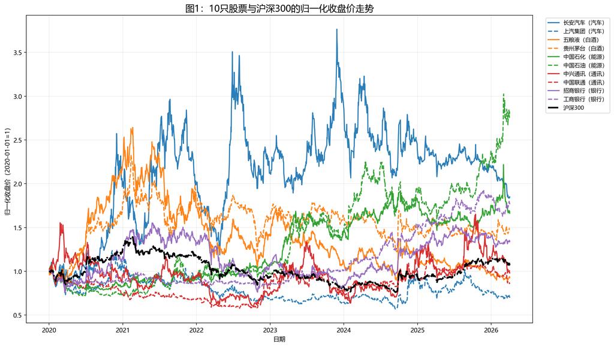

```python
display_png(OUTPUT_DIR / "fig1_normalized_close.png", width=950)
```

归一化走势展示了 10 只股票与沪深300在同一基准下的相对表现。若某只股票曲线长期高于指数，说明其累计涨幅跑赢市场；若长期低于指数，则意味着其相对收益较弱。

从行业角度看，走势的分化反映了不同板块在样本期间受到的政策、景气度和市场偏好影响不同。该图为后续 Beta 解释提供了直观背景，因为高 Beta 股票往往在市场上行和下行阶段表现出更大的弹性。

### 图2：日收益率分布图

下面代码会优先读取前面分析 Notebook 已经生成好的 PNG 图片。  
如果图片存在，会直接嵌入报告；如果图片缺失，则提示你先重新运行相应分析 Notebook。

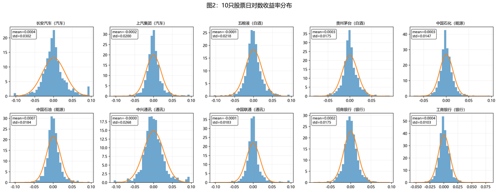

```python
display_png(OUTPUT_DIR / "fig2_return_distribution.png", width=950)
```

收益率分布图帮助我们判断个股收益是否近似正态，以及是否存在明显偏态和厚尾现象。若柱状图相对尖峭或尾部较长，则意味着极端收益发生的概率高于正态分布所暗示的水平。

这对于金融建模非常重要，因为 CAPM 和 OLS 回归通常依赖较为规则的误差结构假设。若收益分布明显偏离正态，则说明市场中存在事件冲击、情绪波动或行业特定风险。

### 图3：收益率相关系数热力图

下面代码会优先读取前面分析 Notebook 已经生成好的 PNG 图片。  
如果图片存在，会直接嵌入报告；如果图片缺失，则提示你先重新运行相应分析 Notebook。

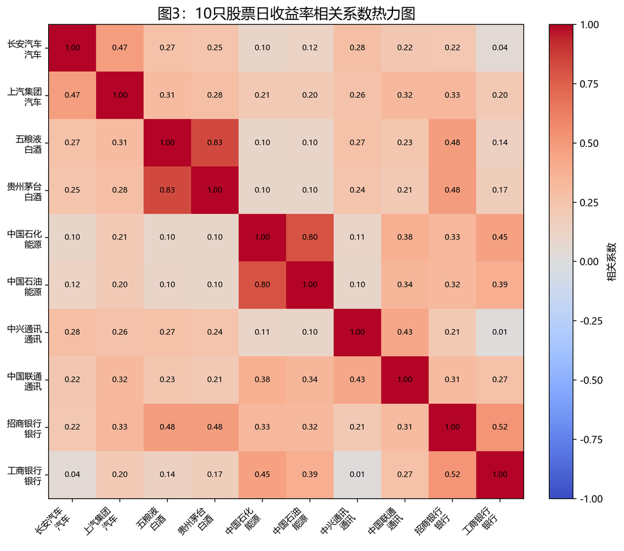

```python
display_png(OUTPUT_DIR / "fig3_corr_heatmap.png", width=950)
```

相关系数热力图展示了 10 只股票日收益率之间的联动关系。若同一行业内部的相关系数普遍更高，说明行业共同因子在短期收益波动中发挥了较强作用。

该图也帮助我们理解为什么 CAPM 的单一市场因子并不能完全解释所有股票波动。除了市场风险之外，行业风险和公司特质同样会影响个股收益率的相关结构。

### 图4：宏观指标与沪深300月收益率关系

下面代码会优先读取前面分析 Notebook 已经生成好的 PNG 图片。  
如果图片存在，会直接嵌入报告；如果图片缺失，则提示你先重新运行相应分析 Notebook。

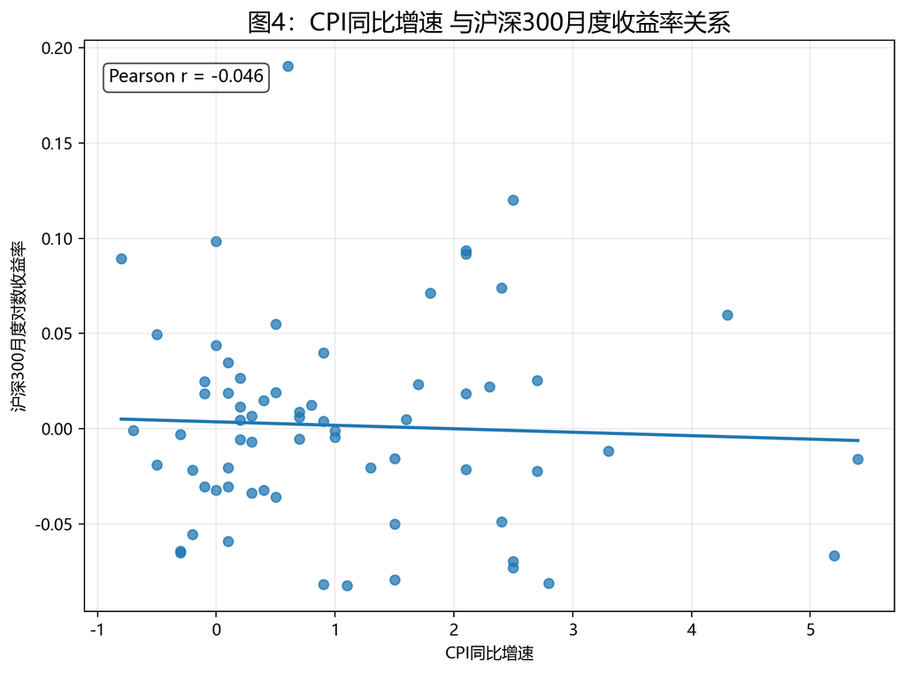

```python
display_png(OUTPUT_DIR / "fig4_macro_vs_hs300.png", width=950)
```

散点图与线性拟合线用于刻画宏观变量与市场收益率之间的方向关系。若拟合线斜率为正，说明宏观指标上升可能伴随市场收益率改善；若为负，则说明二者可能存在反向关系。

不过，这种关系更多反映样本内的统计相关，而不是严格的因果识别。金融市场对宏观变量的响应还会受到政策预期、行业结构与风险偏好的共同影响。

### 图5：ROE 跨公司对比（选做）

下面代码会优先读取前面分析 Notebook 已经生成好的 PNG 图片。  
如果图片存在，会直接嵌入报告；如果图片缺失，则提示你先重新运行相应分析 Notebook。

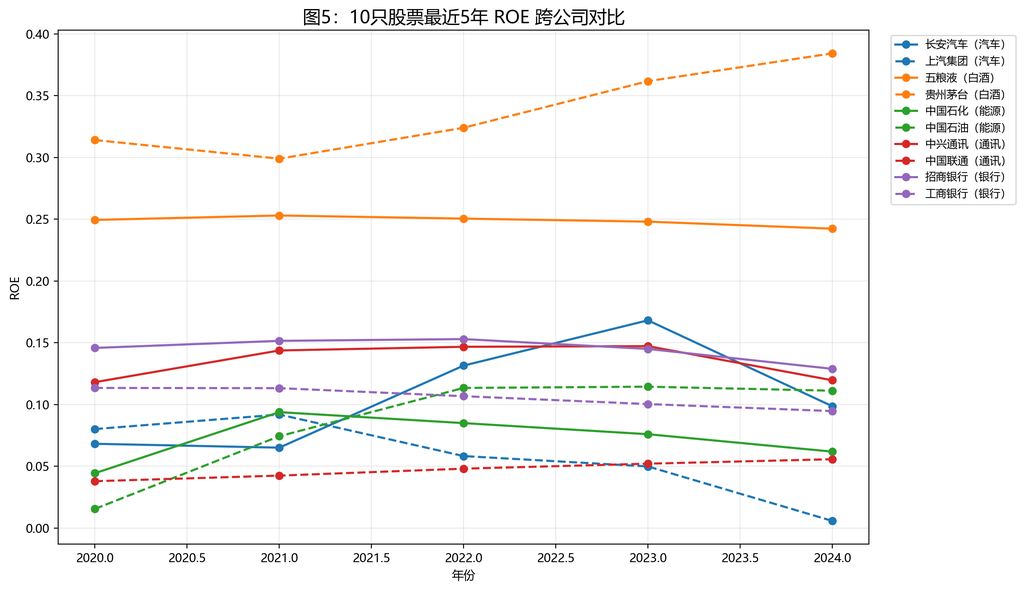

```python
display_png(OUTPUT_DIR / "fig5_roe_comparison.png", width=950)
```

ROE 图展示了不同公司在最近几年盈利能力上的相对水平。若某行业 ROE 整体更高且更稳定，通常意味着该行业的盈利模式更成熟，资本回报能力更强。

但需要注意，ROE 高并不必然代表股票收益率一定更高，因为估值、成长预期、市场风格和风险溢价也会影响股价表现。因此，财务指标更适合作为补充解释，而不是收益的唯一依据。

## 4.4 核心代码示例：描述统计与归一化价格

下面的代码块展示第四部分中两类最重要的操作：  
一类是以日对数收益率计算年化统计量；另一类是把收盘价归一化后用于横向比较。

把这部分核心代码放进报告，能够清晰体现“描述性统计”和“可视化”是如何建立在同一套基础数据变换之上的。

```python
if stock_clean is not None:
    temp = stock_clean.copy().sort_values(["code", "date"])
    temp["log_return"] = temp.groupby("code")["close"].transform(lambda s: np.log(s / s.shift(1)))

    annual_stats = (
        temp.groupby("code")["log_return"]
        .agg(["mean", "std"])
        .reset_index()
        .rename(columns={"mean": "日均值", "std": "日波动率"})
    )
    annual_stats["年化均值"] = annual_stats["日均值"] * 252
    annual_stats["年化波动率"] = annual_stats["日波动率"] * np.sqrt(252)
    display(annual_stats.head())

    temp["normalized_close"] = temp.groupby("code")["close"].transform(lambda s: s / s.iloc[0])
    display(temp[["date", "code", "close", "normalized_close"]].head(10))
else:
    print("未找到 stock_clean 数据。")
```

|  | code | 日均值 | 日波动率 | 年化均值 | 年化波动率 |
| --- | --- | --- | --- | --- | --- |
| 0 | 000063 | -0.000013 | 0.026850 | -0.003283 | 0.426226 |
| 1 | 000625 | 0.000406 | 0.030244 | 0.102386 | 0.480105 |
| 2 | 000858 | -0.000051 | 0.021766 | -0.012957 | 0.345522 |
| 3 | 600028 | 0.000336 | 0.014710 | 0.084676 | 0.233507 |
| 4 | 600036 | 0.000193 | 0.017471 | 0.048576 | 0.277347 |

|  | date | code | close | normalized_close |
| --- | --- | --- | --- | --- |
| 0 | 2020-01-02 | 000063 | 447.732791 | 1.000000 |
| 1 | 2020-01-03 | 000063 | 461.625769 | 1.031030 |
| 2 | 2020-01-06 | 000063 | 463.520266 | 1.035261 |
| 3 | 2020-01-07 | 000063 | 462.257268 | 1.032440 |
| 4 | 2020-01-08 | 000063 | 451.016586 | 1.007334 |
| 5 | 2020-01-09 | 000063 | 467.561860 | 1.044288 |
| 6 | 2020-01-10 | 000063 | 471.856053 | 1.053879 |
| 7 | 2020-01-13 | 000063 | 479.434041 | 1.070804 |
| 8 | 2020-01-14 | 000063 | 463.646566 | 1.035543 |
| 9 | 2020-01-15 | 000063 | 466.298862 | 1.041467 |

# 五、CAPM 与宏观回归分析

## 5.1 回归分析的目的

在完成描述统计和图形分析之后，本项目进一步通过回归分析检验两类问题：

1. **市场因子解释力问题**：个股收益率是否能够用市场收益率来解释？
2. **宏观敏感度问题**：股票月收益率是否会对利率或通胀类变量产生系统性响应？

第一类问题对应 CAPM；第二类问题对应宏观月度回归。  
这两个模型虽然都属于线性回归，但其经济含义并不相同：前者关注股票对**市场风险**的暴露，后者关注股票对**宏观环境变化**的敏感度。

## 5.2 模型设定

### CAPM 模型

[ r_{i,t}-r_f = \alpha_i + \beta_i(r_{m,t}-r_f)+\varepsilon_{i,t} ]

其中：

- (r_{i,t})：个股日对数收益率
- (r_{m,t})：沪深300日对数收益率
- (r_f)：无风险利率，统一设为年化 2%，并折算为日频

### 宏观月度回归

- (r^{月}_{i,t})：个股月度对数收益率
- (X_t)：选定的宏观指标（优先使用 1年期LPR；若缺失则使用 CPI 同比增速）
- (\gamma_i)：个股对宏观变量变化的敏感系数

```python
capm_results = safe_read_csv(OUTPUT_DIR / "capm_results.csv", dtype={"code": str})
capm_table = safe_read_csv(OUTPUT_DIR / "capm_results_table.csv")

macro_reg_results = safe_read_csv(OUTPUT_DIR / "macro_monthly_regression_results.csv", dtype={"code": str})
macro_reg_table = safe_read_csv(OUTPUT_DIR / "macro_monthly_regression_table.csv")

print("CAPM 回归结果表：")
display(capm_table if capm_table is not None else capm_results)

print("宏观月度回归结果表：")
display(macro_reg_table if macro_reg_table is not None else macro_reg_results)
```

```
CAPM 回归结果表：
```

|  | 股票 | 行业 | α̂ | p值 | β̂ | 95% CI | R² |
| --- | --- | --- | --- | --- | --- | --- | --- |
| 0 | 长安汽车 | 汽车 | 0.000369 | 0.590596 | 1.202423 | [1.089, 1.316] | 0.222787 |
| 1 | 上汽集团 | 汽车 | -0.000289 | 0.515121 | 0.851517 | [0.778, 0.925] | 0.255971 |
| 2 | 五粮液 | 白酒 | -0.000086 | 0.829203 | 1.294468 | [1.229, 1.360] | 0.498515 |
| 3 | 贵州茅台 | 白酒 | 0.000219 | 0.513846 | 0.977210 | [0.922, 1.033] | 0.441981 |
| 4 | 中国石油 | 能源 | 0.000621 | 0.169444 | 0.468492 | [0.394, 0.543] | 0.091014 |
| 5 | 中国石化 | 能源 | 0.000269 | 0.455923 | 0.366755 | [0.307, 0.426] | 0.087619 |
| 6 | 中兴通讯 | 通讯 | -0.000056 | 0.922040 | 1.244047 | [1.149, 1.339] | 0.302661 |
| 7 | 中国联通 | 通讯 | -0.000150 | 0.719032 | 0.713985 | [0.645, 0.783] | 0.215004 |
| 8 | 招商银行 | 银行 | 0.000145 | 0.682380 | 0.904849 | [0.846, 0.963] | 0.378054 |
| 9 | 工商银行 | 银行 | 0.000304 | 0.232736 | 0.222173 | [0.180, 0.264] | 0.066211 |

```
宏观月度回归结果表：
```

|  | 股票 | 行业 | 宏观指标 | γ̂ | p值 | 95% CI | R² |
| --- | --- | --- | --- | --- | --- | --- | --- |
| 0 | 长安汽车 | 汽车 | 1年期LPR | 0.062787 | 0.267619 | [-0.049, 0.175] | 0.017040 |
| 1 | 上汽集团 | 汽车 | 1年期LPR | -0.009898 | 0.745941 | [-0.071, 0.051] | 0.001467 |
| 2 | 五粮液 | 白酒 | 1年期LPR | 0.037861 | 0.312459 | [-0.036, 0.112] | 0.014167 |
| 3 | 贵州茅台 | 白酒 | 1年期LPR | 0.033106 | 0.270219 | [-0.026, 0.093] | 0.016858 |
| 4 | 中国石化 | 能源 | 1年期LPR | 0.006455 | 0.761975 | [-0.036, 0.049] | 0.001282 |
| 5 | 中国石油 | 能源 | 1年期LPR | -0.026856 | 0.362554 | [-0.085, 0.032] | 0.011527 |
| 6 | 中国联通 | 通讯 | 1年期LPR | -0.005343 | 0.826772 | [-0.054, 0.043] | 0.000670 |
| 7 | 中兴通讯 | 通讯 | 1年期LPR | -0.008155 | 0.844511 | [-0.091, 0.074] | 0.000538 |
| 8 | 招商银行 | 银行 | 1年期LPR | -0.006486 | 0.821823 | [-0.064, 0.051] | 0.000709 |
| 9 | 工商银行 | 银行 | 1年期LPR | -0.027492 | 0.048530 | [-0.055, -0.000] | 0.052970 |

```python
if capm_results is not None and len(capm_results) > 0:
    beta_col = "beta_hat"
    alpha_p_col = "alpha_p_value"
    r2_col = "r_squared"
    stock_col = "stock" if "stock" in capm_results.columns else "股票"
    ind_col = "industry" if "industry" in capm_results.columns else "行业"

    high_beta = capm_results[capm_results[beta_col] > 1]
    high_beta_text = "、".join(
        [f"{r[stock_col]}（{r[ind_col]}，β={r[beta_col]:.2f}）" for _, r in high_beta.iterrows()]
    ) if len(high_beta) > 0 else "样本中没有 β 大于 1 的股票"

    sig_alpha = capm_results[capm_results[alpha_p_col] < 0.05]
    sig_alpha_text = "、".join(
        [f"{r[stock_col]}（p={r[alpha_p_col]:.4f}）" for _, r in sig_alpha.iterrows()]
    ) if len(sig_alpha) > 0 else "样本中 α 在 5% 水平下大多不显著"

    top_r2 = capm_results.loc[capm_results[r2_col].idxmax()]
    low_r2 = capm_results.loc[capm_results[r2_col].idxmin()]

    md = f"""
**CAPM 结果文字解读**

从 Beta 估计看，β 大于 1 的股票包括：{high_beta_text}。这类股票对市场波动更敏感，若主要集中在汽车、能源、通讯等行业，通常与“周期性行业风险暴露更高”的经验判断一致；相反，若白酒或银行中的部分股票 β 较低，则更接近稳健或防御性风格。

从 Alpha 的显著性看，{sig_alpha_text}。如果某些股票的 α 显著不为零，说明在控制市场超额收益后，这些股票仍存在无法被 CAPM 单因子完全解释的异常收益；如果 α 大多不显著，则说明市场因子已经解释了收益的主要系统性部分。

从 R² 来看，解释力最高的股票是 **{top_r2[stock_col]}**（{top_r2[ind_col]}，R²={top_r2[r2_col]:.3f}），最低的是 **{low_r2[stock_col]}**（{low_r2[ind_col]}，R²={low_r2[r2_col]:.3f}）。这意味着前者收益波动更贴近市场组合，而后者可能受到更多行业冲击、公司事件或特质风险的影响。
"""
    display(Markdown(md))
```

**CAPM 结果文字解读**

从 Beta 估计看，β 大于 1 的股票包括：长安汽车（汽车，β=1.20）、五粮液（白酒，β=1.29）、中兴通讯（通讯，β=1.24）。这类股票对市场波动更敏感，若主要集中在汽车、能源、通讯等行业，通常与“周期性行业风险暴露更高”的经验判断一致；相反，若白酒或银行中的部分股票 β 较低，则更接近稳健或防御性风格。

从 Alpha 的显著性看，样本中 α 在 5% 水平下大多不显著。如果某些股票的 α 显著不为零，说明在控制市场超额收益后，这些股票仍存在无法被 CAPM 单因子完全解释的异常收益；如果 α 大多不显著，则说明市场因子已经解释了收益的主要系统性部分。

从 R² 来看，解释力最高的股票是 **五粮液**（白酒，R²=0.499），最低的是 **工商银行**（银行，R²=0.066）。这意味着前者收益波动更贴近市场组合，而后者可能受到更多行业冲击、公司事件或特质风险的影响。

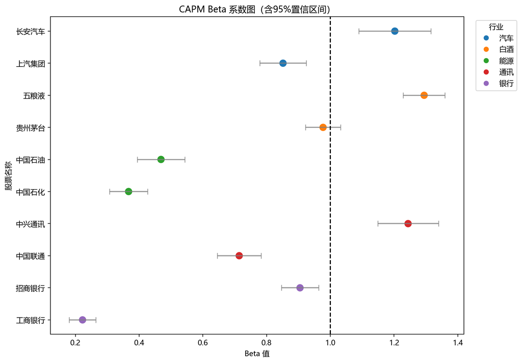

```python
display_png(OUTPUT_DIR / "fig_capm_beta.png", width=900)
```

CAPM 的 Beta 系数图把回归表中的数字可视化，有助于同时观察点估计与置信区间。  
若某只股票的置信区间整体位于 1 上方，通常意味着它对市场波动的弹性显著较高；若区间穿过 1，则说明其市场风险暴露并不显著偏离整体市场水平。

从行业分组着色可以进一步看出：同一行业内部的 Beta 可能相近，但并不完全一致。  
这说明行业属性虽然重要，但公司自身经营模式、资本结构和投资者预期也会共同决定个股的系统性风险暴露程度。

```python
if macro_reg_results is not None and len(macro_reg_results) > 0:
    gamma_col = "gamma_hat"
    p_col = "gamma_p_value"
    stock_col = "stock" if "stock" in macro_reg_results.columns else "股票"
    ind_col = "industry" if "industry" in macro_reg_results.columns else "行业"
    macro_name = macro_reg_results["macro_indicator"].iloc[0] if "macro_indicator" in macro_reg_results.columns else "宏观指标"

    macro_reg_results["abs_gamma_tmp"] = macro_reg_results[gamma_col].abs()
    top_gamma = macro_reg_results.sort_values("abs_gamma_tmp", ascending=False).head(3)
    top_gamma_text = "、".join(
        [f"{r[stock_col]}（{r[ind_col]}，γ={r[gamma_col]:.4f}）" for _, r in top_gamma.iterrows()]
    )

    ind_sens = (
        macro_reg_results.groupby(ind_col, as_index=False)["abs_gamma_tmp"]
        .mean()
        .sort_values("abs_gamma_tmp", ascending=False)
    )
    high_ind = ind_sens.iloc[0][ind_col]
    low_ind = ind_sens.iloc[-1][ind_col]

    sig_gamma = macro_reg_results[macro_reg_results[p_col] < 0.05]
    sig_gamma_text = "、".join(
        [f"{r[stock_col]}（p={r[p_col]:.4f}）" for _, r in sig_gamma.iterrows()]
    ) if len(sig_gamma) > 0 else "样本中大多数个股对该宏观指标的响应在统计上并不显著"

    md = f"""
**宏观月度回归结果文字解读**

本部分选取的宏观变量为 **{macro_name}**。从系数绝对值看，最敏感的股票主要包括：{top_gamma_text}。这说明这些股票的月度收益率对宏观环境变化的响应更强，背后可能与融资成本、贴现率、需求预期或行业景气周期有关。

从行业差异看，平均敏感度较高的行业是 **{high_ind}**，相对较低的行业是 **{low_ind}**。若所选宏观指标是利率变量，那么资本开支大、杠杆高或估值依赖贴现率的行业往往更敏感；若是 CPI 等通胀指标，则成本传导能力和定价权强弱会影响收益率的反应方向和强度。

从显著性看，{sig_gamma_text}。因此，在样本期内，宏观变量对个股收益率的影响并非在所有公司上都同样明显，而是存在较强的异质性。
"""
    display(Markdown(md))
```

**宏观月度回归结果文字解读**

本部分选取的宏观变量为 **1年期LPR**。从系数绝对值看，最敏感的股票主要包括：长安汽车（汽车，γ=0.0628）、五粮液（白酒，γ=0.0379）、贵州茅台（白酒，γ=0.0331）。这说明这些股票的月度收益率对宏观环境变化的响应更强，背后可能与融资成本、贴现率、需求预期或行业景气周期有关。

从行业差异看，平均敏感度较高的行业是 **汽车**，相对较低的行业是 **通讯**。若所选宏观指标是利率变量，那么资本开支大、杠杆高或估值依赖贴现率的行业往往更敏感；若是 CPI 等通胀指标，则成本传导能力和定价权强弱会影响收益率的反应方向和强度。

从显著性看，工商银行（p=0.0485）。因此，在样本期内，宏观变量对个股收益率的影响并非在所有公司上都同样明显，而是存在较强的异质性。

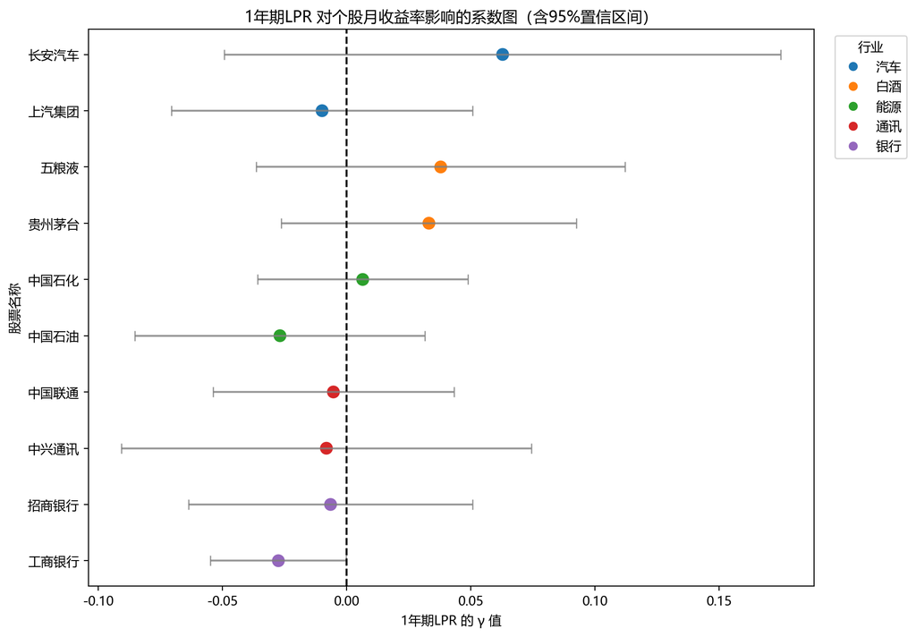

```python
display_png(OUTPUT_DIR / "fig_macro_gamma.png", width=900)
```

宏观敏感性系数图的意义在于，它把“股票对宏观变量的反应差异”直接表现出来。  
若某些行业的点估计明显偏离 0，且置信区间较窄，则说明该宏观变量对这些行业的影响更稳定、更具方向性。

不过，这种结果仍应审慎解释。  
一方面，月度样本量通常显著少于日度样本；另一方面，宏观变量对股价的作用往往伴随着政策预期、市场风格和行业冲击共同变化，因此回归系数更多体现样本内关系，而不是严格因果效应。

## 5.3 核心代码示例：OLS 回归框架

下面的代码块展示第五部分回归分析的基本模板。  
它既适用于 CAPM，也适用于宏观月度回归，本质上都是“构造被解释变量与解释变量 → 加常数项 → 用 OLS 拟合 → 提取系数与显著性”。

将其纳入报告，可以清晰向读者说明：最终结论并非主观判断，而是建立在可重复的回归估计过程之上。

```python
import statsmodels.api as sm

if stock_clean is not None and index_300 is not None:
    temp_stock = stock_clean.copy().sort_values(["code", "date"])
    temp_stock["log_return"] = temp_stock.groupby("code")["close"].transform(lambda s: np.log(s / s.shift(1)))

    temp_index = index_300.copy().sort_values("date")
    temp_index["market_log_return"] = np.log(temp_index["close"] / temp_index["close"].shift(1))

    first_code = temp_stock["code"].dropna().astype(str).iloc[0]
    demo = temp_stock[temp_stock["code"] == first_code][["date", "log_return"]].merge(
        temp_index[["date", "market_log_return"]],
        on="date",
        how="inner"
    ).dropna()

    y = demo["log_return"]
    X = sm.add_constant(demo["market_log_return"])
    model = sm.OLS(y, X).fit()

    print(model.summary())
else:
    print("缺少 stock_clean 或 index_000300 数据，无法展示 OLS 示例。")
```

```
                            OLS Regression Results
==============================================================================
Dep. Variable:             log_return   R-squared:                       0.303
Model:                            OLS   Adj. R-squared:                  0.302
Method:                 Least Squares   F-statistic:                     655.4
Date:                Sun, 05 Apr 2026   Prob (F-statistic):          2.35e-120
Time:                        21:05:23   Log-Likelihood:                 3597.3
No. Observations:                1512   AIC:                            -7191.
Df Residuals:                    1510   BIC:                            -7180.
Df Model:                           1
Covariance Type:            nonrobust
=====================================================================================
                        coef    std err          t      P>|t|      [0.025      0.975]
-------------------------------------------------------------------------------------
const             -7.583e-05      0.001     -0.131      0.895      -0.001       0.001
market_log_return     1.2440      0.049     25.600      0.000       1.149       1.339
==============================================================================
Omnibus:                      187.299   Durbin-Watson:                   2.033
Prob(Omnibus):                  0.000   Jarque-Bera (JB):              796.417
Skew:                           0.523   Prob(JB):                    1.15e-173
Kurtosis:                       6.398   Cond. No.                         84.2
==============================================================================

Notes:
[1] Standard Errors assume that the covariance matrix of the errors is correctly specified.
```

# 六、结论、局限与可改进方向

## 6.2 本项目的局限性

尽管本报告已经完成课程作业所要求的完整分析流程，但从严格研究角度看，仍存在若干限制：

- 样本股票数量较少，仅用于教学分析，不能代表全部 A 股市场；
- 宏观变量数量有限，难以全面刻画多重宏观冲击；
- 回归模型以线性框架为主，未进一步考虑多因子扩展、异方差修正或稳健性检验；
- 月度宏观回归的样本量相对较小，系数解释应保持谨慎；
- 报告主要目标是复现与规范表达，不以严格学术论文的识别策略为目标。

## 6.3 可改进方向

如果在本作业基础上继续深化，后续可以从以下方向扩展：

1. 将单因子 CAPM 扩展为 Fama-French 三因子或多因子模型；
2. 引入更多宏观变量，如汇率、M2、工业增加值等，比较不同变量的解释力；
3. 采用滚动窗口估计 Beta，分析系统性风险暴露随时间变化的动态特征；
4. 在行业层面构建组合收益率，而不仅仅分析单只股票；
5. 结合事件窗口或政策冲击，进一步识别异常收益与行业敏感度来源。

## 报告结语

本次作业完整覆盖了金融数据分析的一个基础工作流：  
从数据获取、数据管理与清洗，到统计刻画、图形展示，再到回归建模与结果解释，形成了一个较完整的实证分析闭环。

从课程训练角度看，这一流程的价值不仅在于“得到若干结果”，更在于理解：  
**高质量的金融分析，始终建立在规范的数据结构、清晰的方法设计与有逻辑的文字解释之上。**

````python
final_check = pd.DataFrame([
    file_info(ROOT / "README.md"),
    file_info(CLEAN_DIR / "stock_clean.csv"),
    file_info(CLEAN_DIR / "stock_clean.parquet"),
    file_info(COMBINED_DIR / "combined_data.csv"),
    file_info(OUTPUT_DIR / "descriptive_stats.csv"),
    file_info(OUTPUT_DIR / "fig1_normalized_close.png"),
    file_info(OUTPUT_DIR / "fig2_return_distribution.png"),
    file_info(OUTPUT_DIR / "fig3_corr_heatmap.png"),
    file_info(OUTPUT_DIR / "fig4_macro_vs_hs300.png"),
    file_info(OUTPUT_DIR / "fig5_roe_comparison.png"),
    file_info(OUTPUT_DIR / "capm_results.csv"),
    file_info(OUTPUT_DIR / "fig_capm_beta.png"),
    file_info(OUTPUT_DIR / "macro_monthly_regression_results.csv"),
    file_info(OUTPUT_DIR / "fig_macro_gamma.png"),
])

display(final_check)

display(Markdown("""
**导出建议：**

1. 先点击 **Run All**，确保所有表格、图像和文字输出全部生成；
2. 确认图片都能正常显示后，再通过 VSCode 或 `jupyter nbconvert` 导出；
3. 建议最终导出文件名为 `report.pdf`。

示例命令：

```bash
jupyter nbconvert --to pdf report.ipynb --output report.pdf
```
"""))
````

|  | path | exists | size_kb |
| --- | --- | --- | --- |
| 0 | d:\Microsoft VS Code\dshw-p01\README.md | True | 5.68 |
| 1 | d:\Microsoft VS Code\dshw-p01\data\clean\stock... | True | 1732.32 |
| 2 | d:\Microsoft VS Code\dshw-p01\data\clean\stock... | True | 856.80 |
| 3 | d:\Microsoft VS Code\dshw-p01\data\combined\co... | True | 2908.78 |
| 4 | d:\Microsoft VS Code\dshw-p01\output\descripti... | True | 1.30 |
| 5 | d:\Microsoft VS Code\dshw-p01\output\fig1_norm... | True | 815.55 |
| 6 | d:\Microsoft VS Code\dshw-p01\output\fig2_retu... | True | 317.36 |
| 7 | d:\Microsoft VS Code\dshw-p01\output\fig3_corr... | True | 245.24 |
| 8 | d:\Microsoft VS Code\dshw-p01\output\fig4_macr... | True | 113.08 |
| 9 | d:\Microsoft VS Code\dshw-p01\output\fig5_roe_... | True | 230.20 |
| 10 | d:\Microsoft VS Code\dshw-p01\output\capm_resu... | True | 1.75 |
| 11 | d:\Microsoft VS Code\dshw-p01\output\fig_capm_... | True | 98.00 |
| 12 | d:\Microsoft VS Code\dshw-p01\output\macro_mon... | True | 1.71 |
| 13 | d:\Microsoft VS Code\dshw-p01\output\fig_macro... | True | 106.79 |

**导出建议：**

1. 先点击 **Run All**，确保所有表格、图像和文字输出全部生成；

2. 确认图片都能正常显示后，再通过 VSCode 或 `jupyter nbconvert` 导出；

3. 建议最终导出文件名为 `report.pdf`。

示例命令：

```
jupyter nbconvert --to pdf report.ipynb --output report.pdf
```